# lab_4 IDA

```
VotingClassifier(estimators=[('log_reg1', LogisticRegression()),
                             ('mlp1', MLPClassifier(max_iter=600)),
                             ('mlp2', MLPClassifier(max_iter=600))],
                 voting='soft')
```

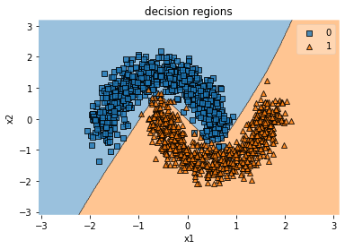

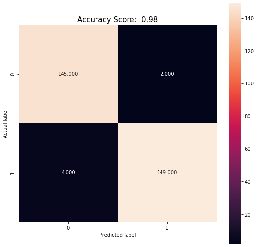

```
Precision-score:  0.98
Recall-score:  0.98
F1-score:  0.98
```

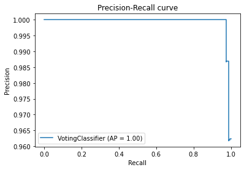

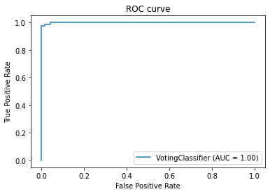

```
VotingClassifier(estimators=[('log_reg1', LogisticRegression()),
                             ('mlp1', MLPClassifier(max_iter=600)),
                             ('mlp2', MLPClassifier(max_iter=600))],
                 voting='soft', weights=[0.2, 0.4, 0.4])
```

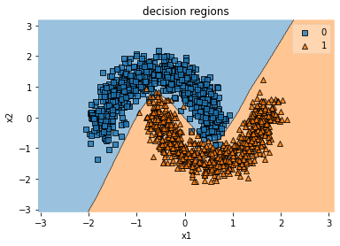

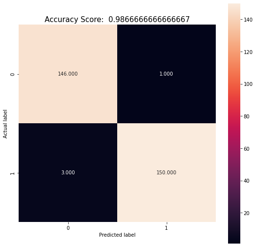

```
Precision-score:  0.9866666666666667
Recall-score:  0.9866666666666667
F1-score:  0.9866666666666668
```

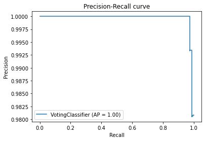

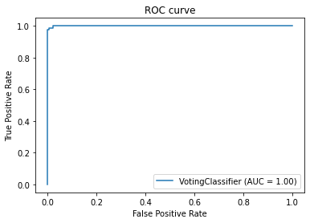

```
VotingClassifier(estimators=[('log_reg1', LogisticRegression()),
                             ('mlp1', MLPClassifier(max_iter=600)),
                             ('mlp2', MLPClassifier(max_iter=600))],
                 voting='soft', weights=[0.5, 0.25, 0.25])
```

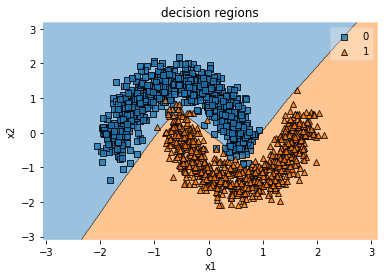

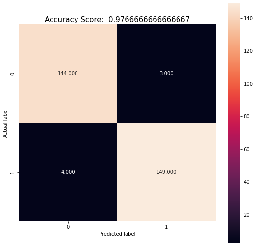

```
Precision-score:  0.9766666666666667
Recall-score:  0.9766666666666667
F1-score:  0.9766666666666667
```

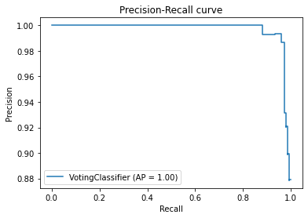

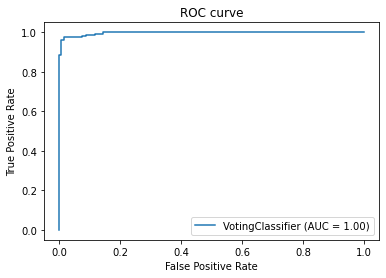

```python
for wgt in weights_m:
    ens_moons_soft = VotingClassifier(estimators = estimators_m,
                                      voting='soft',
                                      weights = wgt).fit(X_moons_train, y_moons_train)
    print(ens_moons_soft)
    decision_regions(X_moons, y_moons, ens_moons_soft)
    estimate(ens_moons_soft, X_moons_test, y_moons_test, 2)
```

#### Датасет load_digits:

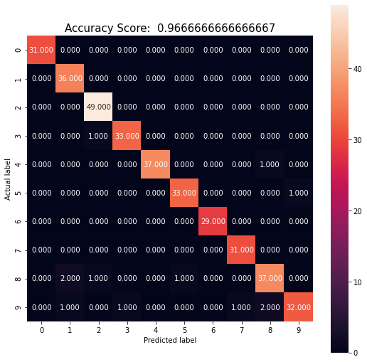

```
Precision-score:  0.9666666666666667
Recall-score:  0.9666666666666667
F1-score:  0.9666666666666667
```

```python
ens_digits_hard = VotingClassifier(estimators = estimators_d,
                                  voting='hard').fit(X_digits_train, y_digits_train)
create_matrix(ens_digits_hard, X_digits_test, y_digits_test)
```

```
VotingClassifier(estimators=[('log_reg1', LogisticRegression()),
                             ('log_reg2', LogisticRegression()),
                             ('mlp2', MLPClassifier(max_iter=600))],
                 voting='soft')
```

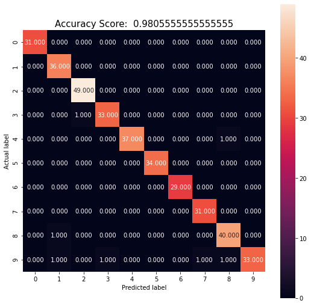

```
Precision-score:  0.9805555555555555
Recall-score:  0.9805555555555555
F1-score:  0.9805555555555555
```

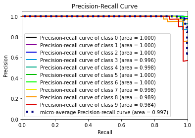

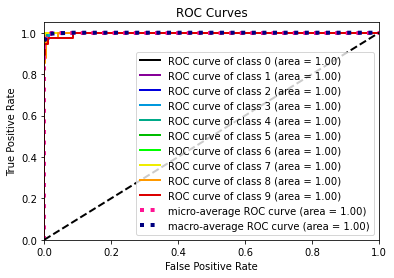

```
VotingClassifier(estimators=[('log_reg1', LogisticRegression()),
                             ('log_reg2', LogisticRegression()),
                             ('mlp2', MLPClassifier(max_iter=600))],
                 voting='soft', weights=[0.2, 0.4, 0.4])
```

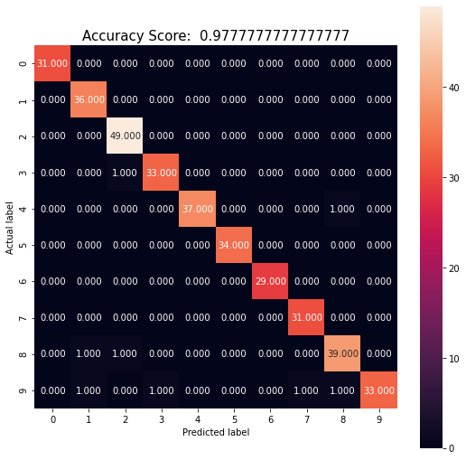

```
Precision-score:  0.9777777777777777
Recall-score:  0.9777777777777777
F1-score:  0.9777777777777777
```

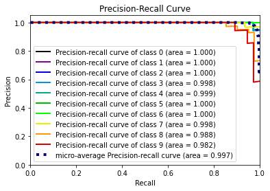

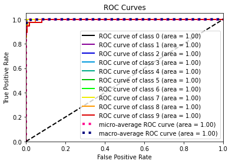

```
VotingClassifier(estimators=[('log_reg1', LogisticRegression()),
                             ('log_reg2', LogisticRegression()),
                             ('mlp2', MLPClassifier(max_iter=600))],
                 voting='soft', weights=[0.5, 0.25, 0.25])
```

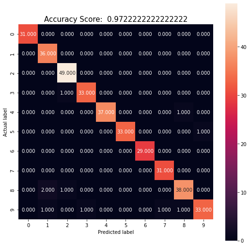

```
Precision-score:  0.9722222222222222
Recall-score:  0.9722222222222222
F1-score:  0.9722222222222222
```

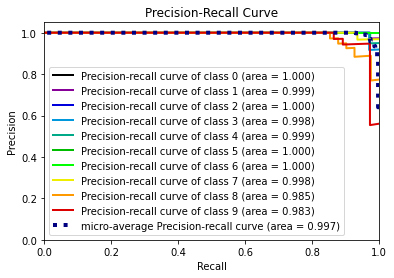

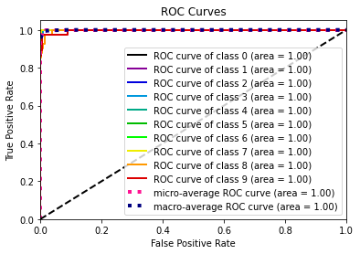

```python
for wgt in weights_d:
    ens_digits_soft = VotingClassifier(estimators = estimators_d,
                                      voting='soft',
                                      weights = wgt).fit(X_digits_train, y_digits_train)
    print(ens_digits_soft)
    estimate(ens_digits_soft, X_digits_test, y_digits_test, 10)
```

### 7. Побудувати ансамблi на основi найкращої моделi / моделей нейронних мереж, знайдених на попереднiх етапах даної роботи, та найкращої моделi / моделей, знайдених у роботi №2.

##### Dataset make_moons:

```python
best_lg_m = LogisticRegression(max_iter=1000, solver='liblinear', C=1.0, penalty='l2')
best_mlp_m1 = MLPClassifier(activation='tanh', alpha=0.01, hidden_layer_sizes=(100, 50, 100), max_iter=10000, solver='adam')
best_mlp_m2 = MLPClassifier(activation='tanh', alpha=0.01, hidden_layer_sizes=(100, 50, 100), max_iter=10000, solver='adam')
```

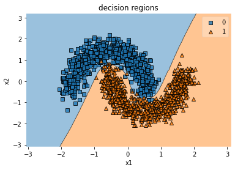

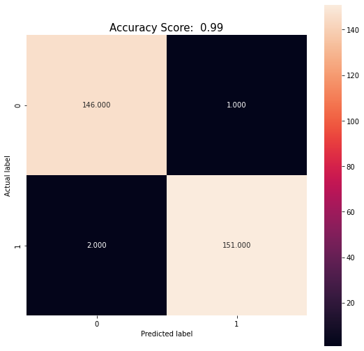

```
Precision-score:  0.99
Recall-score:  0.99
F1-score:  0.99
```

```python
best_ens_moons = VotingClassifier(estimators = [('log_reg', best_lg_m),
                                                ('mlp1', best_mlp_m1),
                                                ('mlp2', best_mlp_m2)],
                                  voting='hard').fit(X_moons_train, y_moons_train)
decision_regions(X_moons, y_moons, best_ens_moons)
create_matrix(ens_moons_hard, X_moons_test, y_moons_test)
```

##### Dataset load_digits:

```python
best_lg_d = LogisticRegression()
best_mlp_d1 = MLPClassifier(activation='relu', alpha=0.1, hidden_layer_sizes=(100, 50), max_iter=10000, solver='adam')
best_mlp_d2 = MLPClassifier(activation='relu', alpha=0.1, hidden_layer_sizes=(100, 50), max_iter=10000, solver='adam')
```

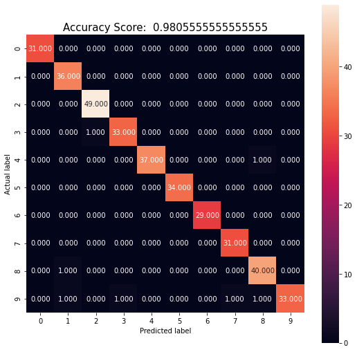

```
Precision-score:  0.9805555555555555
Recall-score:  0.9805555555555555
F1-score:  0.9805555555555555
```

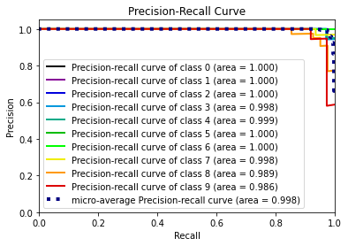

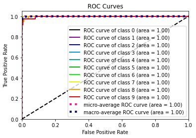

```python
best_ens_digits = VotingClassifier(estimators = [('log_reg', best_lg_d),
                                                ('mlp1', best_mlp_d1),
                                                ('mlp2', best_mlp_d2)],
                                   voting='soft').fit(X_digits_train, y_digits_train)
estimate(best_ens_digits, X_digits_test, y_digits_test, 10)
```

В даній роботі було виконано наступні класифікації:

-нейронними мережами (з різними значеннями параметра hidden_layer_sizes та max_iter)

-ансамблями Voting (використовучи моделі логістичної регресії та нейронних мереж) на основі дефолтних моделей та найкращих моделей за результатами виконання 2 лабораторної та попердніх пунктів даної

Порівнюючи результати, отримані в даній лабораторній роботі та роботі 2, можна зробити висновки:

- для датасету make_moons логістична регресія (враховуючи найкращий випадок, отриманий решітчастим пошуком) є найменш ефективною, що і не дивно, оскільки модель логістичної регресії розбиває площину прикладів на підплощини класів прямою, а так-як маємо півкола, даний алгоритм не може мати досить високу ефекивність. В той же час, використовуючи нейронні мережі та ансамблі з нейронних мереж, отримуються майже ідеальні результати та практично одинакові для обох алгоритмів.
- для датасету load_digits також спостерігається нижча ефективність логістичної регресії, але різниця мір F1 є дуже малою. В даному випадку. Ансамблі та мейронні мережі працюють майже одинаково ефективно

Отже, можна стверджувати про недоцільність використання ансаблів для даних датасетів, оскільки прості моделі, на яких вони побудовані (зокрема нейронні мережі) показують такий же (до того ж майже ідеальний) результат